# 楊子萱_110700049_hw07

楊子萱

2023-11-07

# Introduction

In order to conduct classification models, I decided to use the dataset about **Sleep health and lifestyle**. The classification models I will be using are listed below. To prevent the problem of **over-fitting**, I will split the data into **training** set, **validation** set, and **test** set. I will not only **explain** the results I obtain, but also **compare** the results between different models. Last but not least, I will be discussing some possible problems for future studies.

# Classification Algorithm

```
1. Multinomial Logistic Regression

2. Naive Bayes

3. SVM with Large Margin Linear Classifier

4. SVM with Soft Margin Linear Classifier

5. Nonlinear SVM with a RBS Kernel

6. Nonlinear SVM with a Polynomial Kernel

7. Nonlinear SVM with a Gaussian Kernel

8. Nonlinear SVM with a Sigmoid Kernel

9. K-Nearest Neighbor KNN

10. Random Forest

11. Decision Tree

12. Linear Discriminant Analysis LDA
```

## Check Type & Structure of Data

I will be changing the **character** type variables into **integer**.

**Gender**: Male->0, Female->1

**Sleep.Disorder**: None->1, Sleep Apnea->2, Insomnia->3

**BMI.Category**: Normal, Normal Weight->1, Overweight->2, Obese->3

**Occupations**: Software Engineer->1, Doctor->2, Sales Representative->3, Teacher->4, Nurse->5, Engineer->6, Accountant->7, Scientist->8, Lawyer->9, Salesperson->10, Manager->11

```r
data = read.csv(file = 'Sleep_health_and_lifestyle_dataset.csv', header = TRUE, sep = ',')

data$Gender <- ifelse(data$Gender == "Male", 0, 1)
data$Sleep.Disorder <- factor(data$Sleep.Disorder, levels = c("None", "Sleep Apnea", "Insomnia"), labels = c(0, 1, 2))
data$Sleep.Disorder <- as.numeric(data$Sleep.Disorder)
data$BMI.Category[data$BMI.Category == "Normal Weight"] <- "Normal"
data$BMI.Category <- factor(data$BMI.Category, levels = c("Normal", "Overweight", "Obese"), labels = c(0, 1, 2))
data$BMI.Category <- as.numeric(data$BMI.Category)
occupations <- c("Software Engineer", "Doctor", "Sales Representative", "Teacher", "Nurse", "Engineer", "Accountant", "Scientist", "Lawyer", "Salesperson", "Manager")
data$Occupation <- as.numeric(factor(data$Occupation, levels = occupations))

class(data)
```

```
## [1] "data.frame"
```

```r
str(data)
```

```
## 'data.frame':    374 obs. of  13 variables:
##  $ Person.ID              : int  1 2 3 4 5 6 7 8 9 10 ...
##  $ Gender                 : num  0 0 0 0 0 0 0 0 0 0 ...
##  $ Age                    : int  27 28 28 28 28 28 29 29 29 29 ...
##  $ Occupation             : num  1 2 2 3 3 1 4 2 2 2 ...
##  $ Sleep.Duration         : num  6.1 6.2 6.2 5.9 5.9 5.9 6.3 7.8 7.8 7.8 ...
##  $ Quality.of.Sleep       : int  6 6 6 4 4 4 6 7 7 7 ...
##  $ Physical.Activity.Level: int  42 60 60 30 30 30 40 75 75 75 ...
##  $ Stress.Level           : int  6 8 8 8 8 8 7 6 6 6 ...
##  $ BMI.Category           : num  2 1 1 3 3 3 3 1 1 1 ...
##  $ Blood.Pressure         : chr  "126/83" "125/80" "125/80" "140/90" ...
##  $ Heart.Rate             : int  77 75 75 85 85 85 82 70 70 70 ...
##  $ Daily.Steps            : int  4200 10000 10000 3000 3000 3000 3500 8000 8000 8000 ...
##  $ Sleep.Disorder         : num  1 1 1 2 2 3 3 1 1 1 ...
```

```r
cat("Number of rows with missing values:", sum(!complete.cases(data)), "\n")
```

```
## Number of rows with missing values: 0
```

```r
missing_counts <- colSums(is.na(data))
columns_with_missing <- sum(missing_counts > 0)
cat("Number of columns with missing values:", columns_with_missing, "\n")
```

```
## Number of columns with missing values: 0
```

```r
if (columns_with_missing > 0) {
  cat("Columns with missing values:", paste(names(missing_counts[missing_counts > 0]), collapse = ", "), "\n")
}
```

# Split into Sets

I will split the data into **60%** training, **20%** validation, and **20%** test sets.

```r
set.seed(123)

total_rows <- nrow(data)
indices <- sample(1:total_rows, total_rows)

train_fraction <- 0.6
validation_fraction <- 0.2
test_fraction <- 0.2

train_size <- floor(train_fraction * total_rows)
validation_size <- floor(validation_fraction * total_rows)

train <- data[indices[1:train_size], ]
valid <- data[indices[(train_size + 1):(train_size + validation_size)], ]
test <- data[indices[(train_size + validation_size + 1):total_rows], ]

n_train <- nrow(train)
n_valid <- nrow(valid)
n_test <- nrow(test)

cat("Number of data points in the training set:", n_train, "\n")
```

```
## Number of data points in the training set: 224
```

```r
cat("Number of data points in the validation set:", n_valid, "\n")
```

```
## Number of data points in the validation set: 74
```

```r
cat("Number of data points in the test set:", n_test, "\n")
```

```
## Number of data points in the test set: 76
```

## Summary of Correlation

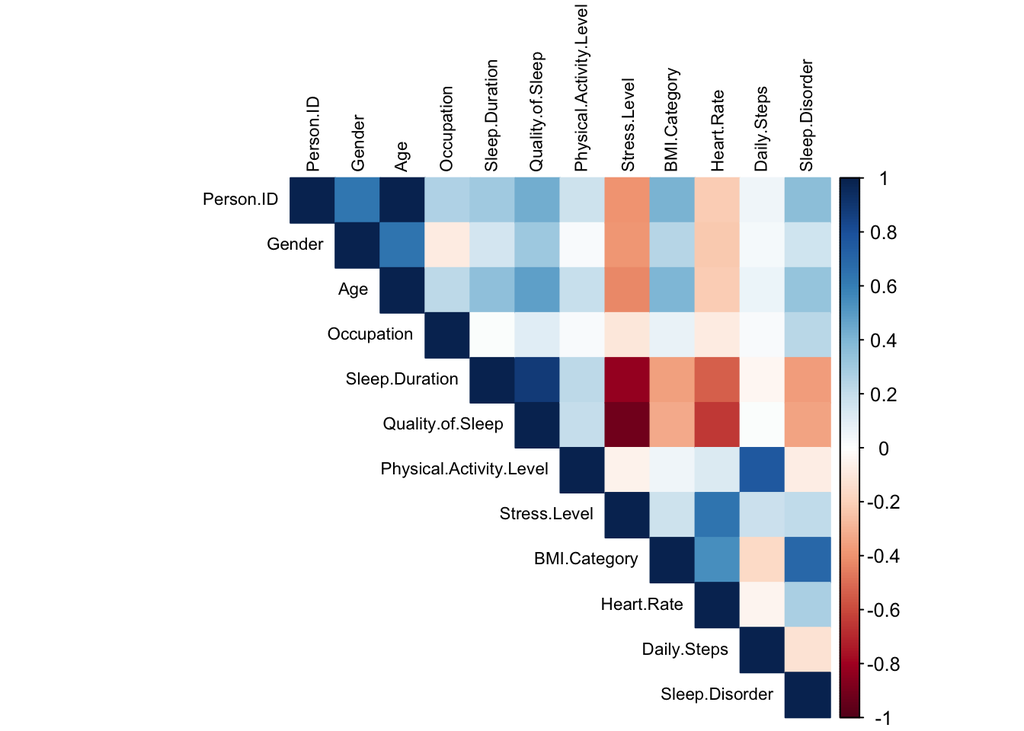

```r
library(corrplot)
num_col <- sapply(train, function(x) is.numeric(x))
num <- train[, num_col]

correlation_matrix <- cor(num, use = "complete.obs")

corrplot(correlation_matrix,
         method = "color",
         type = "upper",
         tl.cex = 0.7,
         tl.col = "black"
)
```

# Classification Algorithm

Since I wanted to find out what affects the **quality of sleep**, this will be my target variable. Then, I chose the variables according to my domain knowledge and some suggestions from the correlation matrix. The chosen feature variables are **“Sleep.Duration”**, **“Age**,** ”Gender**, **“Stress.Level”**, **“Sleep.Disorder”**, and **“Heart.Rate”**.

## 1. Multinomial Logistic Regression

### Training & Evaluation

```r
library(nnet)
library(irr)
library(Metrics)
library(pROC)
model <- multinom(Quality.of.Sleep ~ Sleep.Duration + Age + Gender + Stress.Level + Sleep.Disorder + Heart.Rate, data = train)
```

```
## AUC - Class 1 : 0.9907407
```

```
## AUC - Class 2 : 0.995283
```

```
## AUC - Class 3 : 0.5
```

```
## AUC - Class 4 : 0.5
```

```
## AUC - Class 5 : 0.5
```

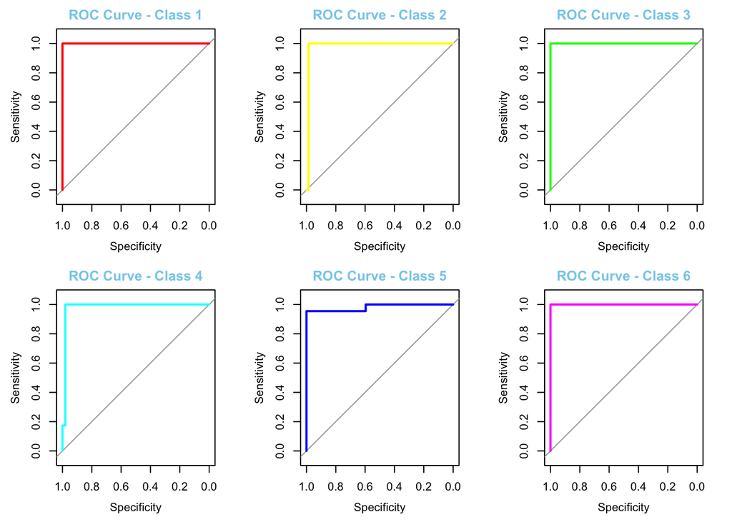

```
## AUC - Class 6 : 0.9883721
```

```r
train$Quality.of.Sleep <- factor(train$Quality.of.Sleep)
valid$Quality.of.Sleep <- factor(valid$Quality.of.Sleep, levels = levels(train$Quality.of.Sleep))

predicted_classes <- predict(model, newdata = valid, type = "class")
predicted_prob <- predict(model, newdata = valid, type = "probs")
true_labels <- as.numeric(factor(valid$Quality.of.Sleep))

confusion_matrix <- table(Actual = valid$Quality.of.Sleep, Predicted = predicted_classes)
accuracy <- sum(diag(confusion_matrix)) / sum(confusion_matrix)
precision <- diag(confusion_matrix) / rowSums(confusion_matrix)
recall <- diag(confusion_matrix) / colSums(confusion_matrix)
f1_score <- 2 * (precision * recall) / (precision + recall)
overall_precision <- mean(precision, na.rm = TRUE)
overall_recall <- mean(recall, na.rm = TRUE)
overall_f1_score <- mean(f1_score, na.rm = TRUE)
kappa <- kappam.fleiss(confusion_matrix)$value

intersection <- sum(diag(confusion_matrix))
union <- sum(confusion_matrix) + sum(confusion_matrix) - sum(diag(confusion_matrix))
jaccard_index <- intersection / union

roc <- multiclass.roc(valid$Quality.of.Sleep, predicted_prob)
class_names <- levels(valid$Quality.of.Sleep)

par(mfrow = c(2, 3))
auc_values <- numeric(ncol(predicted_prob))
for (i in 1:ncol(predicted_prob)) {
  class_labels <- ifelse(valid$Quality.of.Sleep == levels(valid$Quality.of.Sleep)[i], 1, 0)
  roc_curve <- roc(class_labels, predicted_prob[, i])
  auc_values[i] <- auc(roc_curve$sensitivities, 1 - roc_curve$specificities)
  plot(roc_curve, col = rainbow(6)[i], main = paste("ROC Curve - Class", i), col.main = "skyblue")
  cat("AUC - Class", i, ":", auc_values[i], "\n")
}
```

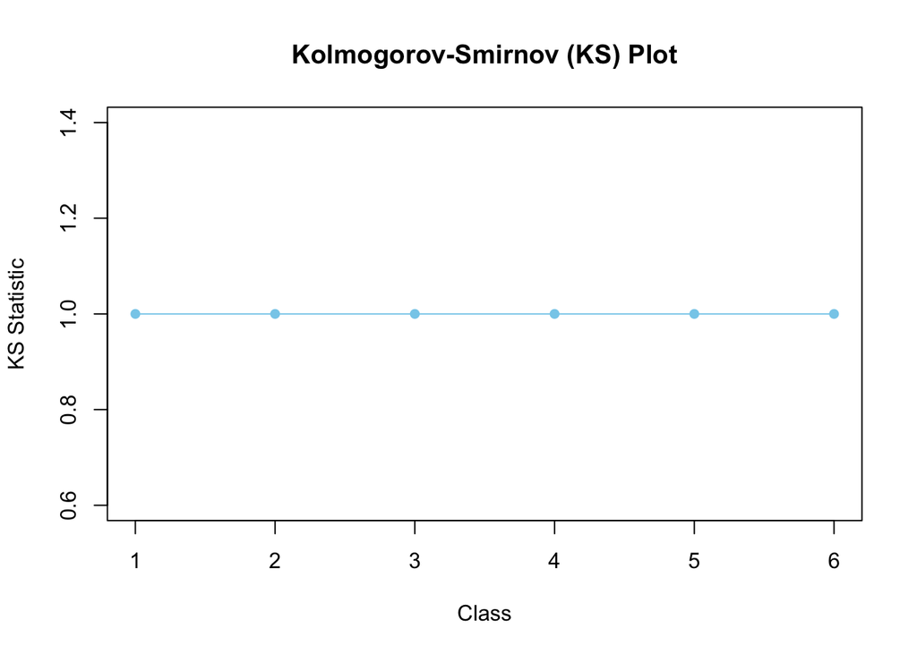

```r
par(mfrow = c(1, 1))

ks_statistic <- numeric(ncol(predicted_prob))
for (i in 1:ncol(predicted_prob)) {
  roc_curve <- roc(ifelse(true_labels == i, 1, 0), predicted_prob[, i])
  ks_statistic[i] <- max(abs(roc_curve$sensitivities - roc_curve$specificities))
}
plot(ks_statistic, type = "o", pch = 16, col = "skyblue", xlab = "Class", ylab = "KS Statistic", main = "Kolmogorov-Smirnov (KS) Plot")
```

```r
print(confusion_matrix)
```

```
##       Predicted
## Actual  4  5  6  7  8  9
##      4  1  0  0  0  0  0
##      5  0  0  1  0  0  0
##      6  0  0 14  0  0  0
##      7  0  0  0 23  0  0
##      8  0  0  0  1 21  0
##      9  0  0  0  0  0 13
```

```r
cat("Accuracy:", accuracy, "\n")
```

```
## Accuracy: 0.972973
```

```r
cat("Overall Precision:", overall_precision, "\n")
```

```
## Overall Precision: 0.8257576
```

```r
cat("Overall Recall:", overall_recall, "\n")
```

```
## Overall Recall: 0.9783333
```

```r
cat("Overall F1-Score:", overall_f1_score, "\n")
```

```
## Overall F1-Score: 0.984197
```

```r
cat("Cohen's Kappa:", kappa, "\n")
```

```
## Cohen's Kappa: -0.1076923
```

```r
cat("Jaccard Index:", jaccard_index, "\n")
```

```
## Jaccard Index: 0.9473684
```

Out of the 74 valid data points, we can see from the confusion matrix that there’re only **2** observations that have predictions in the incorrect class. These points are actual 5 -> predict 6 and actual 8 -> predict 7. On top of that, by looking at the performance metrics, this model is **performing well**. There is **high** overall accuracy and high precision, recall, F1-Score, and Jaccard index. Nevertheless, the **negative** value of Cohen’s Kappa suggests that the **agreement is worse** than what would be expected by chance. This infers that perhaps the **reliability** of the model’s predictions needs to be taken into account.

### Test Set Evaluation

```
## AUC - Class 1 : 0.9912281
```

```
## AUC - Class 2 : 0.875
```

```
## AUC - Class 3 : 0.5
```

```
## AUC - Class 4 : 0.75
```

```
## AUC - Class 5 : 0.5
```

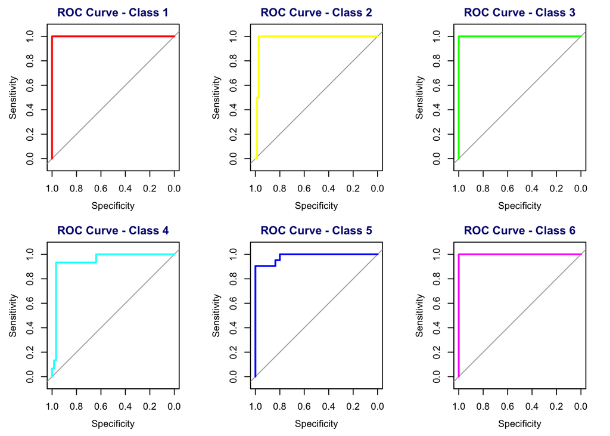

```
## AUC - Class 6 : 0.5
```

```r
test$Quality.of.Sleep <- factor(test$Quality.of.Sleep, levels = levels(train$Quality.of.Sleep))

predicted_test <- predict(model, newdata = test, type = "probs")
predicted_classes_test <- predict(model, newdata = test, type = "class")
true_labels_test <- as.numeric(factor(test$Quality.of.Sleep))

confusion_matrix_test <- table(Actual = test$Quality.of.Sleep, Predicted = predicted_classes_test)

accuracy_test <- sum(diag(confusion_matrix_test)) / sum(confusion_matrix_test)
precision_test <- diag(confusion_matrix_test) / rowSums(confusion_matrix_test)
recall_test <- diag(confusion_matrix_test) / colSums(confusion_matrix_test)
f1_score_test <- 2 * (precision_test * recall_test) / (precision_test + recall_test)
overall_precision_test <- mean(precision_test, na.rm = TRUE)
overall_recall_test <- mean(recall_test, na.rm = TRUE)
overall_f1_score_test <- mean(f1_score_test, na.rm = TRUE)
kappa_test <- kappam.fleiss(confusion_matrix_test)$value

intersection <- sum(diag(confusion_matrix_test))
union <- sum(confusion_matrix_test) + sum(confusion_matrix_test) - sum(diag(confusion_matrix_test))
jaccard_index <- intersection / union

roc <- multiclass.roc(test$Quality.of.Sleep, predicted_test)

par(mfrow = c(2, 3))
auc_values <- numeric(ncol(predicted_test))
for (i in 1:ncol(predicted_test)) {
  class_labels <- ifelse(test$Quality.of.Sleep == levels(test$Quality.of.Sleep)[i], 1, 0)
  roc_curve <- roc(class_labels, predicted_test[, i])
  auc_values[i] <- auc(roc_curve$sensitivities, 1 - roc_curve$specificities)
  plot(roc_curve, col = rainbow(6)[i], main = paste("ROC Curve - Class", i), col.main = "navyblue")
  cat("AUC - Class", i, ":", auc_values[i], "\n")
}
```

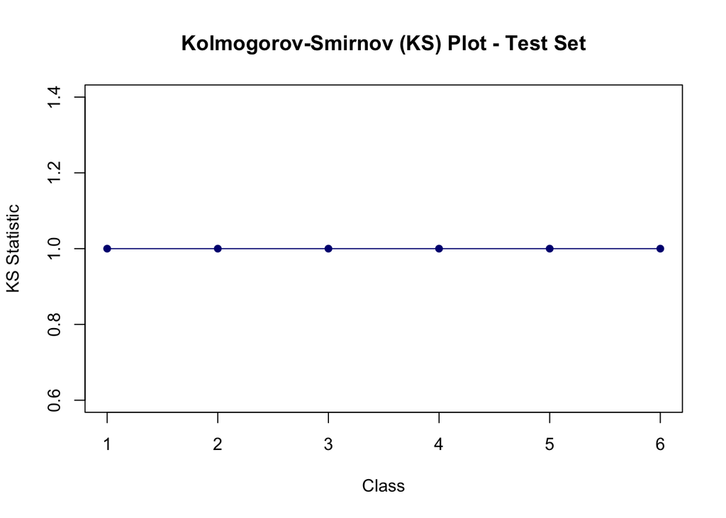

```r
par(mfrow = c(1, 1))

ks_statistic_test <- numeric(ncol(predicted_test))
for (i in 1:ncol(predicted_test)) {
  roc_curve_test <- roc(ifelse(true_labels_test == i, 1, 0), predicted_test[, i])
  ks_statistic_test[i] <- max(abs(roc_curve_test$sensitivities - roc_curve_test$specificities))
}
plot(ks_statistic_test, type = "o", pch = 16, col = "navyblue", xlab = "Class", ylab = "KS Statistic", main = "Kolmogorov-Smirnov (KS) Plot - Test Set")
```

```r
print(confusion_matrix_test)
```

```
##       Predicted
## Actual  4  5  6  7  8  9
##      4  1  0  0  0  0  0
##      5  1  1  0  0  0  0
##      6  0  0 26  0  0  0
##      7  0  1  0 14  0  0
##      8  0  0  0  2 19  0
##      9  0  0  0  0  0 11
```

```r
cat("Accuracy (Test Set):", accuracy_test, "\n")
```

```
## Accuracy (Test Set): 0.9473684
```

```r
cat("Overall Precision (Test Set):", overall_precision_test, "\n")
```

```
## Overall Precision (Test Set): 0.8896825
```

```r
cat("Overall Recall (Test Set):", overall_recall_test, "\n")
```

```
## Overall Recall (Test Set): 0.8125
```

```r
cat("Overall F1-Score (Test Set):", overall_f1_score_test, "\n")
```

```
## Overall F1-Score (Test Set): 0.8366487
```

```r
cat("Cohen's Kappa (Test Set):", kappa_test, "\n")
```

```
## Cohen's Kappa (Test Set): -0.08131868
```

```r
cat("Jaccard Index (Test Set):", jaccard_index, "\n")
```

```
## Jaccard Index (Test Set): 0.9
```

## 2. Naive Bayes

### Training & Evaluation

```r
library(naivebayes)
model_nb <- naive_bayes(Quality.of.Sleep ~ Sleep.Duration + Age + Gender + Stress.Level + Sleep.Disorder + Heart.Rate, data = train)

predicted_nb <- predict(model_nb, newdata = valid, type = "prob")
predicted_classes_nb <- predict(model_nb, newdata = valid, type = "class")
```

```
## AUC - Class 1 : 0.9903846
```

```
## AUC - Class 2 : 0.9907407
```

```
## AUC - Class 3 : 0.5
```

```
## AUC - Class 4 : 0.5
```

```
## AUC - Class 5 : 0.5
```

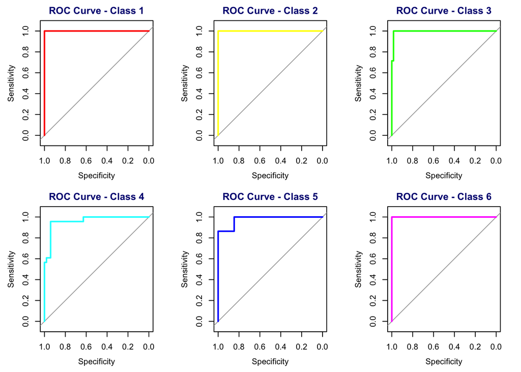

```
## AUC - Class 6 : 0.5
```

```r
roc_obj_nb <- multiclass.roc(valid$Quality.of.Sleep, predicted_nb)
auc_values <- numeric(ncol(predicted_nb))
par(mfrow = c(2, 3))
for (i in 1:ncol(predicted_nb)) {
  class_labels <- ifelse(valid$Quality.of.Sleep == levels(valid$Quality.of.Sleep)[i], 1, 0)
  roc_curve <- roc(class_labels, predicted_nb[, i])
  auc_values[i] <- auc(roc_curve$sensitivities, 1 - roc_curve$specificities)
  plot(roc_curve, col = rainbow(6)[i], main = paste("ROC Curve - Class", i), col.main = "navyblue")
  cat("AUC - Class", i, ":", auc_values[i], "\n")
}
```

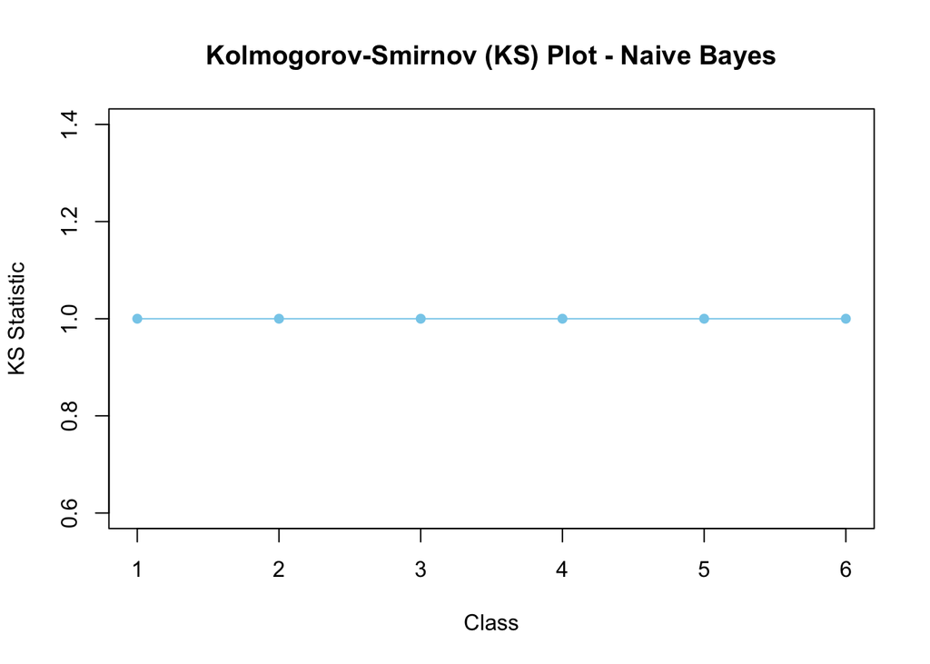

```r
par(mfrow = c(1, 1))

true_labels_nb <- as.numeric(factor(valid$Quality.of.Sleep))
confusion_matrix_nb <- table(Actual = valid$Quality.of.Sleep, Predicted = predicted_classes_nb)

accuracy_nb <- sum(diag(confusion_matrix_nb)) / sum(confusion_matrix_nb)
precision_nb <- diag(confusion_matrix_nb) / rowSums(confusion_matrix_nb)
recall_nb <- diag(confusion_matrix_nb) / colSums(confusion_matrix_nb)
f1_score_nb <- 2 * (precision_nb * recall_nb) / (precision_nb + recall_nb)
overall_precision_nb <- mean(precision_nb, na.rm = TRUE)
overall_recall_nb <- mean(recall_nb, na.rm = TRUE)
overall_f1_score_nb <- mean(f1_score_nb, na.rm = TRUE)
kappa_nb <- kappam.fleiss(confusion_matrix_nb)$value

intersection <- sum(diag(confusion_matrix_nb))
union <- sum(confusion_matrix_nb) + sum(confusion_matrix_nb) - sum(diag(confusion_matrix_nb))
jaccard_index <- intersection / union

ks_statistic_nb <- numeric(ncol(predicted_nb))
for (i in 1:ncol(predicted_nb)) {
  roc_curve_nb <- roc(ifelse(true_labels_nb == i, 1, 0), predicted_nb[, i])
  ks_statistic_nb[i] <- max(abs(roc_curve_nb$sensitivities - roc_curve_nb$specificities))
}
plot(ks_statistic_nb, type = "o", pch = 16, col = "skyblue", xlab = "Class", ylab = "KS Statistic", main = "Kolmogorov-Smirnov (KS) Plot - Naive Bayes")
```

```r
print(confusion_matrix_nb)
```

```
##       Predicted
## Actual  4  5  6  7  8  9
##      4  1  0  0  0  0  0
##      5  0  1  0  0  0  0
##      6  0  3 11  0  0  0
##      7  0  0  1 22  0  0
##      8  0  0  0  3 19  0
##      9  0  0  0  0  0 13
```

```r
cat("Accuracy (Naive Bayes):", accuracy_nb, "\n")
```

```
## Accuracy (Naive Bayes): 0.9054054
```

```r
cat("Overall Precision (Naive Bayes):", overall_precision_nb, "\n")
```

```
## Overall Precision (Naive Bayes): 0.9343121
```

```r
cat("Overall Recall (Naive Bayes):", overall_recall_nb, "\n")
```

```
## Overall Recall (Naive Bayes): 0.8411111
```

```r
cat("Overall F1-Score (Naive Bayes):", overall_f1_score_nb, "\n")
```

```
## Overall F1-Score (Naive Bayes): 0.848275
```

```r
cat("Cohen's Kappa (Naive Bayes):", kappa_nb, "\n")
```

```
## Cohen's Kappa (Naive Bayes): -0.09963636
```

```r
cat("Jaccard Index (Naive Bayes):", jaccard_index, "\n")
```

```
## Jaccard Index (Naive Bayes): 0.8271605
```

Out of the 74 valid data points, we can see from the confusion matrix that there’re **7** observations that have predictions in the incorrect class. On top of that, by looking at the performance metrics, this model is **performing well**. There is **high** overall accuracy and high precision, recall, F1-Score, and Jaccard index. Nevertheless, the **negative** value of Cohen’s Kappa suggests that the **agreement is worse** than what would be expected by chance. This infers that perhaps the **reliability** of the naive bayes model’s predictions needs to be taken into account.

### Test Set Evaluation

```r
predicted_nb_test <- predict(model_nb, newdata = test, type = "prob")
predicted_classes_nb_test <- predict(model_nb, newdata = test, type = "class")
```

```
## AUC - Class 1 : 0.9912281
```

```
## AUC - Class 2 : 0.5
```

```
## AUC - Class 3 : 0.5
```

```
## AUC - Class 4 : 0.5
```

```
## AUC - Class 5 : 0.5
```

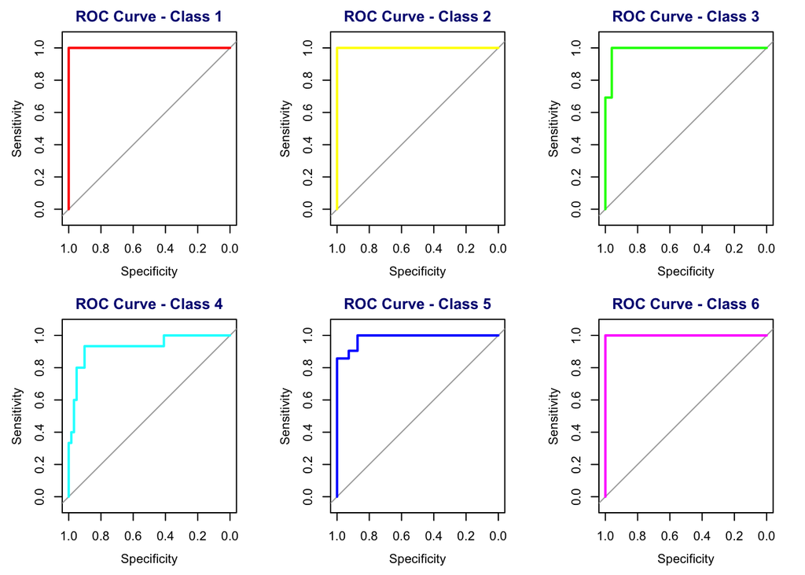

```
## AUC - Class 6 : 0.5
```

```r
roc_obj_nb_test <- multiclass.roc(test$Quality.of.Sleep, predicted_nb_test)
auc_values <- numeric(ncol(predicted_nb_test))
par(mfrow = c(2, 3))
for (i in 1:ncol(predicted_nb_test)) {
  class_labels <- ifelse(test$Quality.of.Sleep == levels(test$Quality.of.Sleep)[i], 1, 0)
  roc_curve <- roc(class_labels, predicted_nb_test[, i])
  auc_values[i] <- auc(roc_curve$sensitivities, 1 - roc_curve$specificities)
  plot(roc_curve, col = rainbow(6)[i], main = paste("ROC Curve - Class", i), col.main = "navyblue")
  cat("AUC - Class", i, ":", auc_values[i], "\n")
}
```

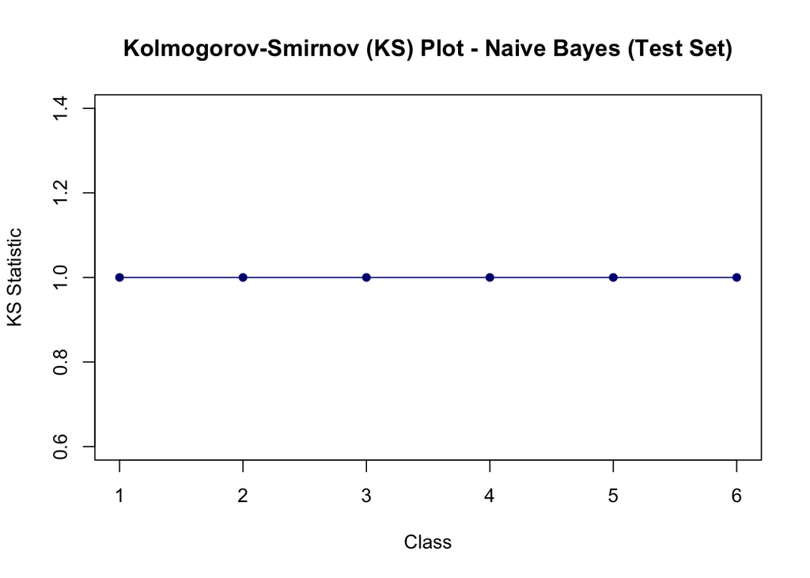

```r
par(mfrow = c(1, 1))

true_labels_nb_test <- as.numeric(factor(test$Quality.of.Sleep))
confusion_matrix_nb_test <- table(Actual = test$Quality.of.Sleep, Predicted = predicted_classes_nb_test)

accuracy_nb_test <- sum(diag(confusion_matrix_nb_test)) / sum(confusion_matrix_nb_test)
precision_nb_test <- diag(confusion_matrix_nb_test) / rowSums(confusion_matrix_nb_test)
recall_nb_test <- diag(confusion_matrix_nb_test) / colSums(confusion_matrix_nb_test)
f1_score_nb_test <- 2 * (precision_nb_test * recall_nb_test) / (precision_nb_test + recall_nb_test)
overall_precision_nb_test <- mean(precision_nb_test, na.rm = TRUE)
overall_recall_nb_test <- mean(recall_nb_test, na.rm = TRUE)
overall_f1_score_nb_test <- mean(f1_score_nb_test, na.rm = TRUE)
kappa_nb_test <- kappam.fleiss(confusion_matrix_nb_test)$value

intersection <- sum(diag(confusion_matrix_nb_test))
union <- sum(confusion_matrix_nb_test) + sum(confusion_matrix_nb_test) - sum(diag(confusion_matrix_nb_test))
jaccard_index <- intersection / union

ks_statistic_nb_test <- numeric(ncol(predicted_nb_test))
for (i in 1:ncol(predicted_nb_test)) {
  roc_curve_nb_test <- roc(ifelse(true_labels_nb_test == i, 1, 0), predicted_nb_test[, i])
  ks_statistic_nb_test[i] <- max(abs(roc_curve_nb_test$sensitivities - roc_curve_nb_test$specificities))
}
plot(ks_statistic_nb_test, type = "o", pch = 16, col = "navyblue", xlab = "Class", ylab = "KS Statistic", main = "Kolmogorov-Smirnov (KS) Plot - Naive Bayes (Test Set)")
```

```r
print(confusion_matrix_nb_test)
```

```
##       Predicted
## Actual  4  5  6  7  8  9
##      4  1  0  0  0  0  0
##      5  0  2  0  0  0  0
##      6  0  7 19  0  0  0
##      7  0  1  2 12  0  0
##      8  0  0  0  3 18  0
##      9  0  0  0  0  1 10
```

```r
cat("Accuracy (Naive Bayes - Test Set):", accuracy_nb_test, "\n")
```

```
## Accuracy (Naive Bayes - Test Set): 0.8157895
```

```r
cat("Overall Precision (Naive Bayes - Test Set):", overall_precision_nb_test, "\n")
```

```
## Overall Precision (Naive Bayes - Test Set): 0.8828338
```

```r
cat("Overall Recall (Naive Bayes - Test Set):", overall_recall_nb_test, "\n")
```

```
## Overall Recall (Naive Bayes - Test Set): 0.8086884
```

```r
cat("Overall F1-Score (Naive Bayes - Test Set):", overall_f1_score_nb_test, "\n")
```

```
## Overall F1-Score (Naive Bayes - Test Set): 0.7990375
```

```r
cat("Cohen's Kappa (Naive Bayes - Test Set):", kappa_nb_test, "\n")
```

```
## Cohen's Kappa (Naive Bayes - Test Set): -0.08220859
```

```r
cat("Jaccard Index (Naive Bayes - Test Set):", jaccard_index, "\n")
```

```
## Jaccard Index (Naive Bayes - Test Set): 0.6888889
```

Out of the 76 test data points, we can see from the confusion matrix that there’re **14** observations that have predictions in the incorrect class. On top of that, by looking at the performance metrics, this model is **alright**, but **not as well as the validation set**. The overall accuracy, precision, recall, F1-Score, and Jaccard index are not as good. Additionally, the value of Cohen’s Kappa is still **negative**, so the **reliability** of the model’s predictions needs to be taken into account.